# 국내 이산화탄소 배출량 증가 요인 분석

## 3) 세 번째 모형: 종속변수에 로그변환을 적용한 다음 모든 변수를 차분한 후 회귀분석 수행

```r
## y에 로그변환 적용
data=read.csv("2조_data.csv")
data$lnCO2=log(data$CO2)
newlnCO2=diff(data$lnCO2, difference=1)
data$newlnCO2 <- c(NA, newlnCO2)
newlnCO2
```

```
##  [1]  0.0454448623 -0.0020557809  0.0853579781  0.1199850561  0.0463905071
##  [6]  0.0401924967  0.0285336868  0.1219510310  0.0490629553  0.1176384889
## [11]  0.0892688930  0.0617860074  0.0919600342  0.0752963488  0.0832665506
## [16]  0.0627533544  0.0519707210 -0.1559591497  0.0896530432  0.1293032707
## [21]  0.0288830229 -0.0076236661  0.0083138533  0.0399197836  0.0002144605
## [26]  0.0195552864  0.0134061974  0.0197967097  0.0163243478  0.0767541579
## [31]  0.0288301075 -0.0075257511 -0.0062375596 -0.0068447221  0.0048511010
```

```r
## 모든 변수 전부 차분
newtemp <- diff(data$temp, difference=1)
data$newtemp <- c(NA, newtemp)
newE.Growth <- diff(data$E.Growth, difference=1)
data$newE.Growth <- c(NA, newE.Growth)
newP.Growth <- diff(data$P.Growth, difference=1)
data$newP.Growth <- c(NA, newP.Growth)
newPower <- diff(data$Power, difference=1)
data$newPower <- c(NA, newPower)
newCoal <- diff(data$Coal, difference=1)
data$newCoal <- c(NA, newCoal)
newRenewable <- diff(data$Renewable, difference=1)
data$newRenewable <- c(NA, newRenewable)
newPetroleum <- diff(data$Petroleum, difference=1)
data$newPetroleum <- c(NA, newPetroleum)
newHydro.E <- diff(data$Hydro.E, difference=1)
data$newHydro.E <- c(NA, newHydro.E)
newNuclear.E <- diff(data$Nuclear.E, difference=1)
data$newNuclear.E <- c(NA, newNuclear.E)
newJapan <- diff(data$Japan, difference=1)
data$newJapan <- c(NA, newJapan)
```

```r
### 종속변수 로그 변환 & 모든 변수 차분 적용한 모형
model_3=lm(newlnCO2~newtemp+newE.Growth+newP.Growth+newCoal+
            newRenewable+newPetroleum+newHydro.E+newNuclear.E+newJapan, data=data)
summary(model_3)
```

```
##
## Call:
## lm(formula = newlnCO2 ~ newtemp + newE.Growth + newP.Growth +
##     newCoal + newRenewable + newPetroleum + newHydro.E + newNuclear.E +
##     newJapan, data = data)
##
## Residuals:
##       Min        1Q    Median        3Q       Max
## -0.075013 -0.017952  0.008711  0.019250  0.045965
##
## Coefficients:
##               Estimate Std. Error t value Pr(>|t|)
## (Intercept)   0.033585   0.012784   2.627  0.01450 *
## newtemp       0.004455   0.011776   0.378  0.70837
## newE.Growth  -0.009723   0.001532  -6.347 1.21e-06 ***
## newP.Growth  -0.017977   0.048038  -0.374  0.71139
## newCoal       0.033602   0.029344   1.145  0.26301
## newRenewable -0.034547   0.011404  -3.029  0.00563 **
## newPetroleum  0.035817   0.014505   2.469  0.02072 *
## newHydro.E   -0.026318   0.024769  -1.063  0.29813
## newNuclear.E  0.008573   0.034420   0.249  0.80533
## newJapan      0.163338   0.179047   0.912  0.37035
## ---
## Signif. codes:  0 '***' 0.001 '**' 0.01 '*' 0.05 '.' 0.1 ' ' 1
##
## Residual standard error: 0.03455 on 25 degrees of freedom
##   (결측으로 인하여 1개의 관측치가 삭제되었습니다.)
## Multiple R-squared:  0.6947, Adjusted R-squared:  0.5847
## F-statistic: 6.319 on 9 and 25 DF,  p-value: 0.0001198
```

```r
## 유의하지 않은 독립변수는 전부 제거한 모형으로 회귀분석 수행
model_3=lm(newlnCO2~newE.Growth+
            newRenewable+newPetroleum, data=data)
summary(model_3)
```

```
##
## Call:
## lm(formula = newlnCO2 ~ newE.Growth + newRenewable + newPetroleum,
##     data = data)
##
## Residuals:
##      Min       1Q   Median       3Q      Max
## -0.08227 -0.02123  0.00354  0.02026  0.05813
##
## Coefficients:
##               Estimate Std. Error t value Pr(>|t|)
## (Intercept)   0.042010   0.007418   5.664 3.20e-06 ***
## newE.Growth  -0.009333   0.001420  -6.572 2.44e-07 ***
## newRenewable -0.033003   0.010354  -3.188  0.00327 **
## newPetroleum  0.034684   0.011566   2.999  0.00530 **
## ---
## Signif. codes:  0 '***' 0.001 '**' 0.01 '*' 0.05 '.' 0.1 ' ' 1
##
## Residual standard error: 0.03329 on 31 degrees of freedom
##   (결측으로 인하여 1개의 관측치가 삭제되었습니다.)
## Multiple R-squared:  0.6484, Adjusted R-squared:  0.6144
## F-statistic: 19.06 on 3 and 31 DF,  p-value: 3.419e-07
```

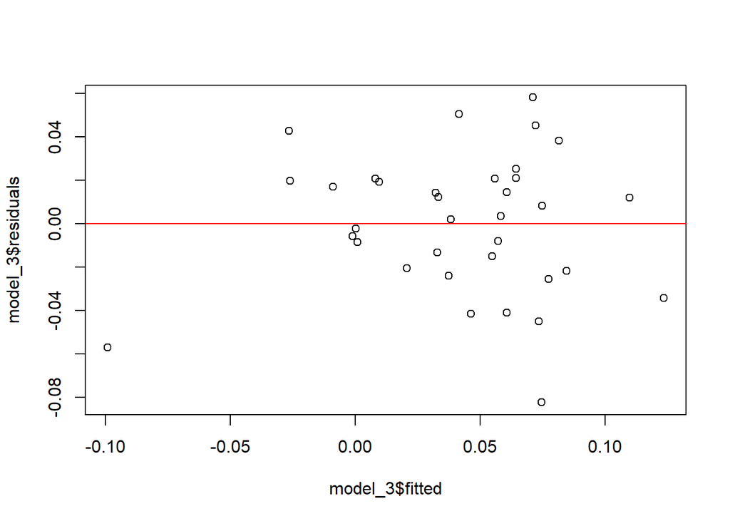

```r
## 등분산성 가정을 만족하는지 확인
plot(model_3$residuals~model_3$fitted)
abline(h=0, col="red")
```

모형2(모든 변수 차분한 모형)보다 분산이 안정되어 보인다.

# 2. 모형 가정 체크

## 가정 1: X와 Y의 scatter plot을 보고 판단

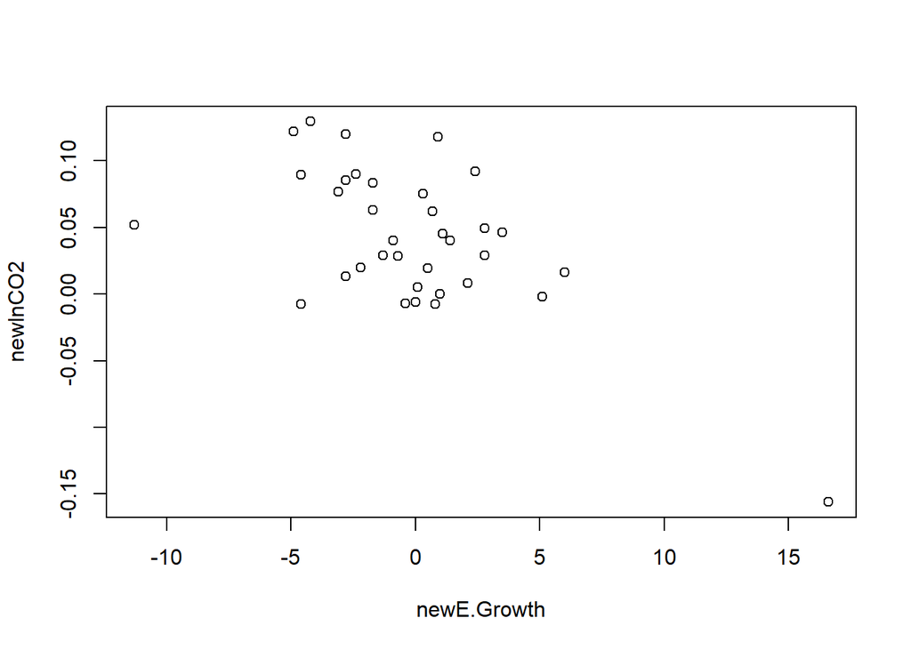

```r
plot(newlnCO2~newE.Growth, data=data)
```

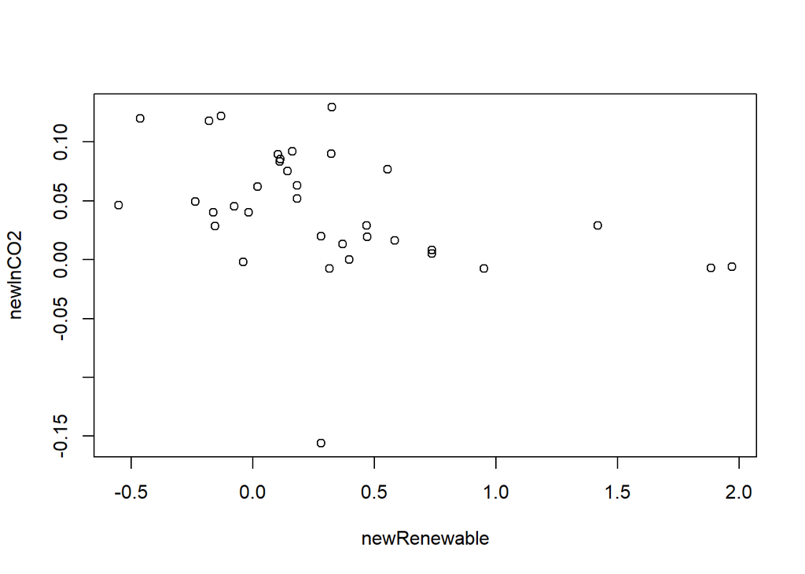

```r
plot(newlnCO2~newRenewable, data=data)
```

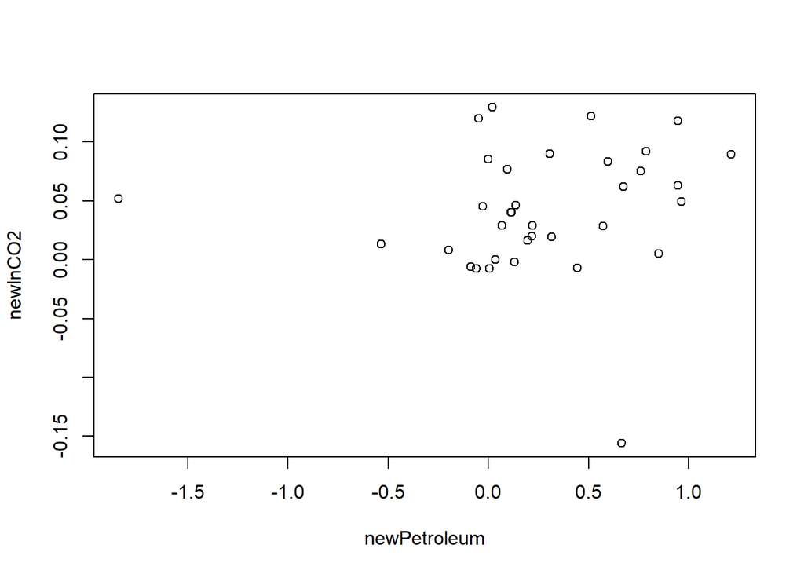

```r
plot(newlnCO2~newPetroleum, data=data)
```

가정 1에 크게 위배되지 않는 것으로 판단된다.

## 가정3, 가정4: 잔차 plot을 보고 판단

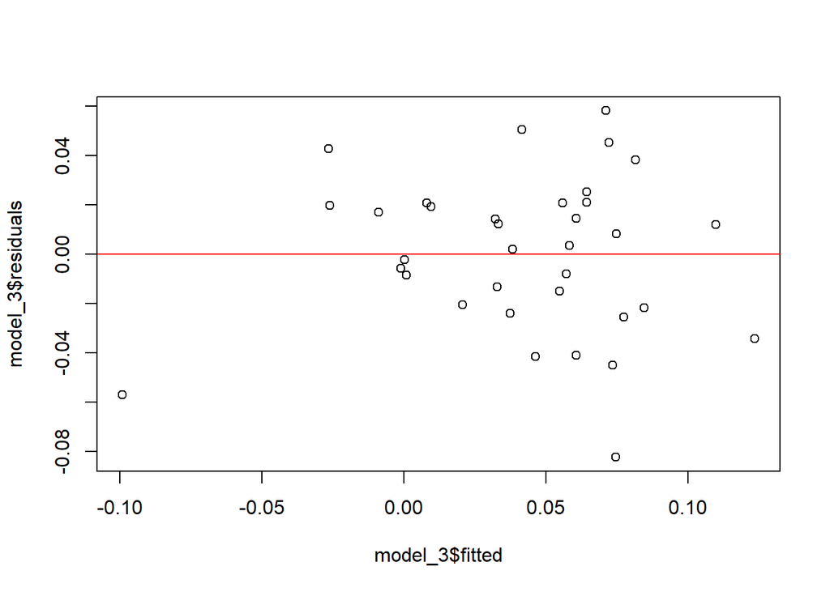

```r
plot(model_3$residuals~model_3$fitted)
abline(h=0, col="red")
```

대체로 가정3과 가정4를 만족하는 것으로 보인다.

## 가정8: 잔차에 대한 히스토그램과 Normal q-q plot으로 판단

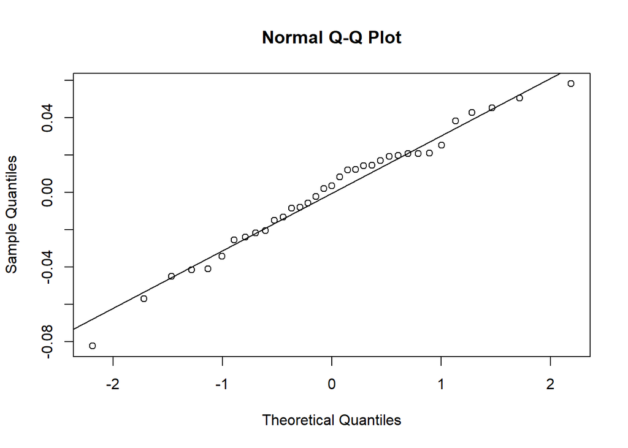

```r
qqnorm(model_3$residuals)
qqline(model_3$residuals)
```

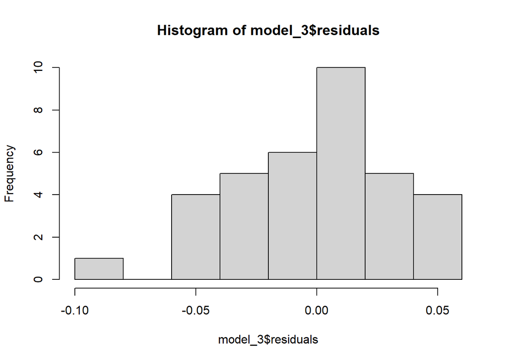

```r
hist(model_3$residuals)
```

q-q plot의 직선 위에 대부분의 점들이 위치해 있음을 확인하였고, 히스토그램 또한 정규분포 모양을 어렴풋이 따르는 것을 확인하여 가정 8을 만족한다고 할 수 있다.

## 가정5: acf 함수, 더빈왓슨 검정으로 확인

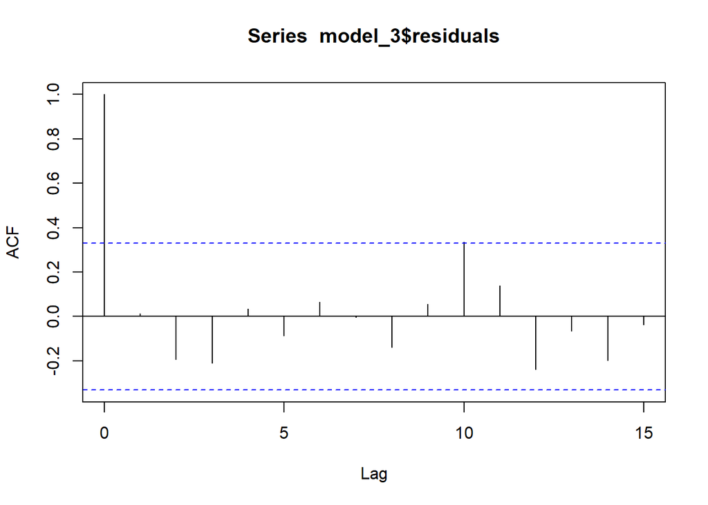

```r
# Autocorrelation
acf(model_3$residuals)
```

acf의 경우 대체적으로 점선을 넘지 않음을 확인하였으나, Lag(10)일 때 점선에 걸쳐지는 애매한 부분이 있어 추가적으로 더빈왓슨 검정을 실시해본다.

```r
# d-w test
# install.packages("lmtest")
library(lmtest)
dwtest(model_3)
```

```
##
##  Durbin-Watson test
##
## data:  model_3
## DW = 1.919, p-value = 0.3541
## alternative hypothesis: true autocorrelation is greater than 0
```

더빈왓슨 검정 결과, p-value = 0.3541로 0.05보다 크므로 H0를 기각하지 못합니다. 따라서 오차의 자기 상관이 존재하지 않는다고 판단된다.

## 가정6: vif를 이용하여 확인

```r
# install.packages("HH")
library(HH)
vif(data[,14:24])
```

```
##     newlnCO2      newtemp  newE.Growth  newP.Growth     newPower      newCoal
##     3.275147     1.341696     3.366500     1.320059     2.582118     2.551645
## newRenewable newPetroleum   newHydro.E newNuclear.E     newJapan
##     1.584231     2.689869     1.216437     1.242028     1.382370
```

모든 변수들의 VIF 값이 10을 넘지 않기 때문에, 해당 모형(세 번째 모형)은 다중공선성이 심하지 않다고 판단된다.